# Teoretická část

## 1 Grammar of graphics

### 1.1 Historie vizualizace dat (stručná)

#### 1.1.1 Minard & Playfair

### 1.2 Zásady vizualizace dat

#### 1.2.1 Tuft

(*The Visual Display of Quantitative Information*; *Tufte’s principles*)

#### 1.2.2 Cleveland

(*Elements of Graphing Data*; *Visualizing Data*)

## 2 Základní grafy v R

Pro vytváření základních grafů v R používáme vestavěný balíček `graphics` [9], který obsahuje mnoho užitečných funkcí pro tvorbu grafických prvků. První kapitola se soustředí na tyto funkce tohoto balíčku a v dalších kapitolách jsou popsány funkce balíčků dalších (například `lattice`, `ggplot2`,…), které zastávají podobné funkce, avšak s různým rozsahem nastavení [10].

V následujících příkladech nejsou grafy doplněny o barvy, popisky os, legendy ani názvy a to především proto, že záměrem této kapitoly je popsat základní grafy a funkce pro jejich tvorbu v prostředí R. Všechny tyto prvky mohou být přidány do grafu, ale tím by příkazy obsahovali irelevantní parametry vzhledem k zaměření této kapitoly. Základní funkce `plot(x)` jejímž voláním se obdrží pole s grafickou reprezentaci proměnné “x”, by při doplnění kódu o veškeré parametry vypadala následovaně [10]:

```r
plot(x, main = "Název grafu", xlab = "popis osy x",
+    ylab = "popis osy y", col = c("red", "black", "green"))
```

Záměrem je tedy používání příkazů s pouze relevantními parametry.

### 2.1 Bodový graf

Bodový graf je rychlým způsobem, jak znázornit vztahy a souvislosti mezi proměnnými datasetu, případně k zjištění jejich neexistence. Data jsou zobrazeny v kartézském souřadném systému a mají pro každou hodnotu proměnné dané místo na vodorovné a svislé ose. V případě existence závislostí mezi proměnnými lze tuto závislost interpolovat přímkou, křivkou či dalším vhodným vyobrazením této závislosti.

Pro vytvoření bodového grafu v základním prostředí R (pomocí `graphics`) použijeme funkci `plot()`, která má tento typ grafu předdefinovaný pro numerické hodnoty. Viz obrázek (a). Nečíselná data vytvoří jiný typ grafu.

```r
plot(cars)
```

### 2.2 Liniový graf

Jediný rozdíl mezi bodovým a liniovým grafem je, že jeden zobrazuje body a druhý je spojuje.[10] (viz. obrázek (a), (b)). Pro vykreslení liniového grafu se používá již několikrát zmíněná funkce `plot()`, kterou doplníme o požadovaný typ vykreslení:

```r
plot(x, type="l")
```

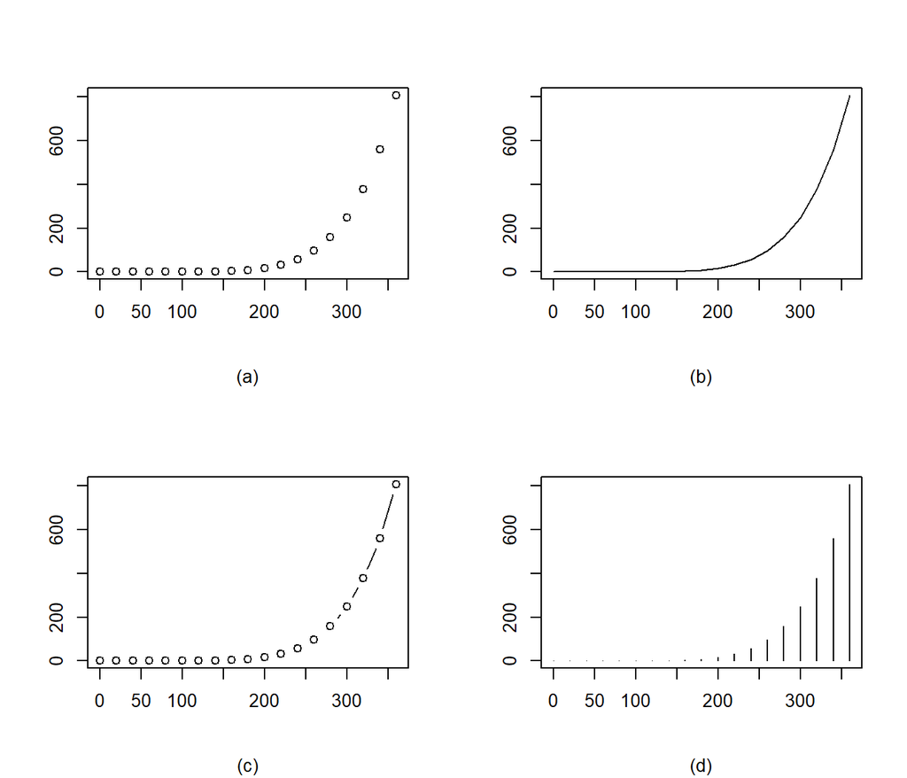

Porovnání základních typů grafů: (a) - bodový, (b) - liniový, (c) - složený, (d) - histogram

Popis a všechny atributy dalších parametrů funkce `plot()` lze nalézt v nápovědě zadáním příkazu `?plot()`.

### 2.3 Vykreslení rozdělení v R

Funkce v R lze vykreslovat pomocí funkce `curve()` z balíčku `graphics`. Lze vykreslit jak standardní funkce, tak i funkce definované uživatelem. Například hustotu pravděpodobnosti normálního rozdělení a její distribuční funkci můžeme vykreslit tímto způsobem (Obrázek ):

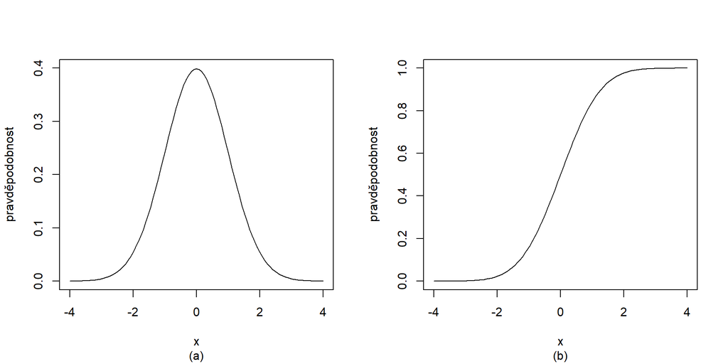

Hustota pravděpodobnosti normálního rozdělení (a) a její distribuční funkce (b)

```r
curve(dnorm(x))
curve(pnorm(x))
```

#### 2.3.1 Q-Q graf a P-P graf

Princip Q-Q grafu spočívá v porovnání dvou rozdělení pravděpodobnosti pomocí vykreslení jejich kvantilů proti sobě. Na jedné ose se nacházejí teoretické kvantily normálního rozdělení a na druhé ose kvantily naměřené (pozorované). Pokud data mají přesně normální rozdělení, všechny body grafu leží na přímce 45°. [10] [2]

Princip P-P grafu je obdobný jako u Q-Q grafu: vykreslují se dvě distribuční funkcí proti sobě (jedná teoretická a jedná pozorovaná) a pokud všechny body grafu leží přibližně na přímce, jedná se o normální rozdělení. Z velké části se P-P graf používá k vyhodnocení koeficientu šikmosti rozdělení.[7]

V R se Q-Q graf vykreslí takto:

```r
qqnorm(x)
qqline(x)
```

P-P graf v R lze vykreslit například následovně:

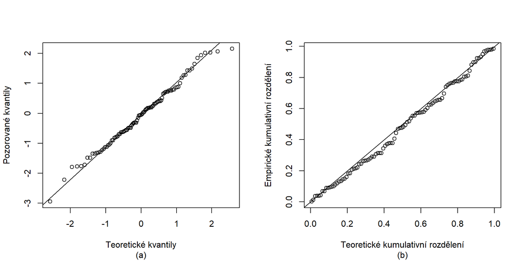

Q-Q Graf (a) a P-P Graf (b)

```r
plot(ppoints(length(x)), sort(pnorm(x)))
abline(0,1)
```

#### 2.3.2 Krabicový graf

Krabicový graf poskytuje rychlé a jednoduché vizuální shrnutí datasetu. V základním prostředí R se vykreslí pomocí funkce `boxplot()` z balíčku `graphics`. Obrázek znázorňuje typický krabicový graf, kde silná čára je medián, krabice kolem ní určuje polohu prvního a třetího kvartilů (dolní Q<sub>1</sub> kvantil 25% a horní Q<sub>3</sub> kvantil 75%). ”Vousy“ (*whiskers*) nad a pod krabici znázorňují rozpětí dat bez odlehlých hodnot. Odlehlé hodnoty jsou definovaný jako hodnoty ležící ve větší vzdálenosti od krabice než 1,5 $\times$ IQR, kde IQR je mezikvartilové rozpětí (*interquartile range*) neboli $Q_3 - Q_1$.

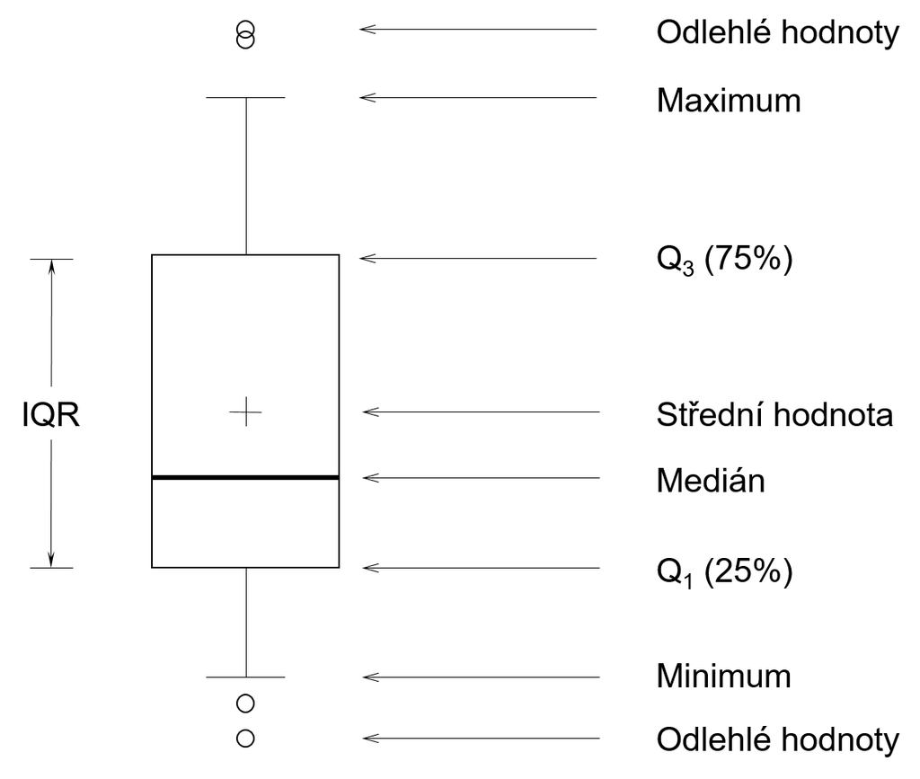

Boxplot

```r
boxplot(x)
```

### 2.4 Sloupcový graf

Sloupcový graf je jedním z nejvíce používaných způsobů vizualizace dat. Obvykle se používá pro zobrazení kvantitativních hodnot na ose y a kvalitativních na ose x. Výška sloupců může reprezentovat jak četnosti výskytu hodnot, tak i samotné hodnoty.[1]

V R lze tento typ grafu vykreslit pomocí funkce `barplot()`. V příkladu (Obrázek ) je použit data set `mtcars`, konkretně atribut `cyl` - počet válců v motoru.

```r
table(mtcars$cyl)
```

```
##
##  4  6  8
## 11  7 14
```

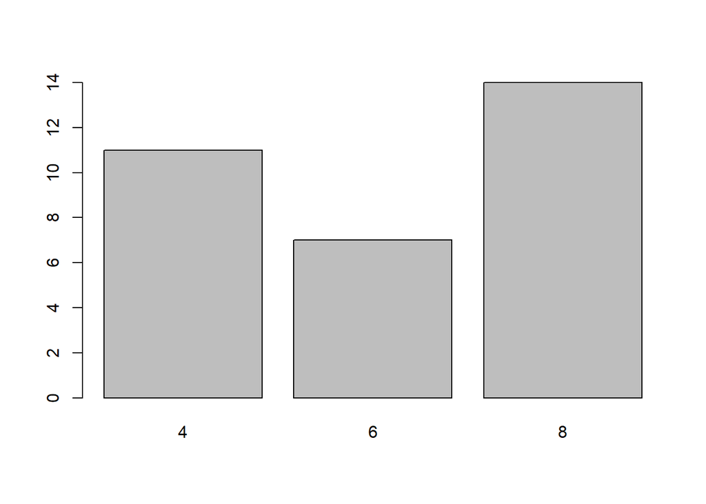

Ukázka jednoduchého sloupcového grafu

```r
barplot(table(mtcars$cyl))
```

### 2.4.1 Histogram

Sloupcový graf s četnostmi na souvislé ose je taky známý jako histogram.[1] Četnosti mohou být absolutní či relativní. Absolutní četnost zobrazuje počet statistických jednotek s hodnotou znaku, který patří do určitého intervalu. Podíl příslušné četnosti a rozsahu datového souboru se nazývá relativní četnost.[6] Šířka sloupce reprezentuje jednotlivé intervaly, které mají stejnou délku. Pro výpočet optimální délky intervalu existují různé metody. Základní histogram se vytváří pomocí funkci `hist()` a její atribut `breaks` udává buď hranice intervalů, jejich preferovaný počet nebo metodu výpočtu intervalu. V R jsou vestavěny 3 metody výpočtu:

1. Sturges [5]

```r
hist(x, breaks = "Sturges")
```

$$k=[log_2(n)]+1$$
Kde $k$ je počet intervalů a $n$ je počet prvků neboli počet pozorování výběru $x$. Tato metoda je výchozí pro funkci `hist()`.

2. Scott [5]

```r
hist(x, breaks = "Scott")
```

Scotovo pravidlo je následující:
$$h=\frac{3.5 \sigma}{n^{\frac{1}{3}}}$$
kde $\sigma$ je směrodatná odchylka a $h$ je předpokládaná šířka intervalu.

Počet intervalů může být vypočítán pomocí vztahu:
$$k=\Big[\frac{max(x)-min(x)}{h}\Big]$$

Případně oba vztahy lze shrnout do jednoho:
$$k = \Big[n^{\frac{1}{3}}{\frac{max(x)-min(x)}{3.5 \sigma}}\Big]$$

3. Freedman–Diaconis [4]

```r
hist(x, breaks = "FD")
```

Freedman–Diaconisovo pravidlo pro stanovení předpokládané šířky intervalu je:

$$h=2\frac{IQR(x)}{n^{\frac{1}{3}}}$$
Po dosazení:
$$k = \Big[n^{\frac{1}{3}}{\frac{max(x)-min(x)}{2IQR(x)}}\Big]$$

kde $IQR$ je mezikvartilové rozpětí, které definujeme jako rozdíl třetího a prvního kvartilů.

Histogram je jedním ze standardních způsobů, používaných k odhadu tvaru rozdělení, přesto se ale tento způsob považuje za nepřesný, vzhledem k ovlivnění tvaru počtem použitých intervalů. Při normálním rozdělení by měl histogram mít zvoncovitý tvar schodný s Gaussovou křivkou (Obrázek ).

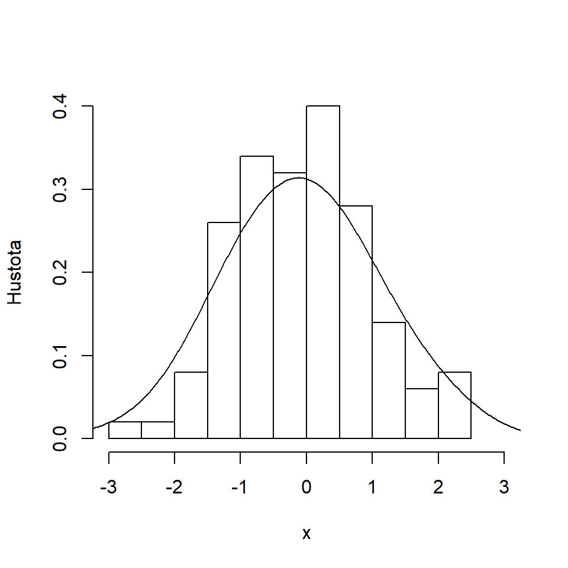

Histogram s odhadem hustoty pravděpodobnosti

#### 2.4.2 Koláčový graf

Koláčový graf představuje plný kruh (360°), který je rozdělen na jednotlivé výseče pro znázornění číselných proporci mezi proměnnými. Koláčový graf je tvořen transformaci skládaného sloupcového grafu do polárního souřadnicového systému (Obrázek ). [12]

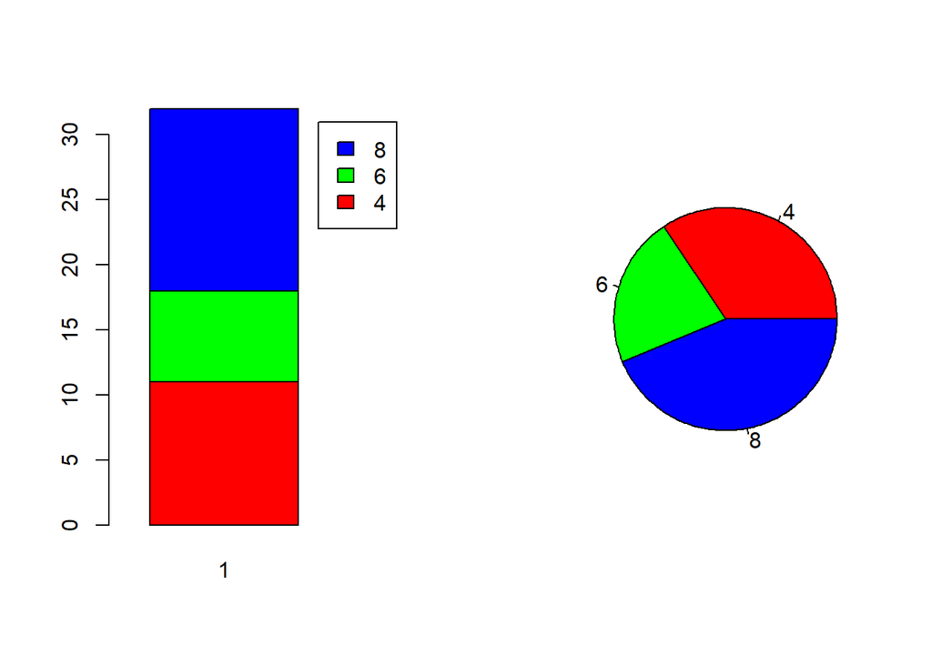

Skládaný sloupcový graf transformovaný do polárního souřadnicového systému

Jednoduché koláčové grafy se vykreslují pomoci funkci `pie()` (Obrázek ).

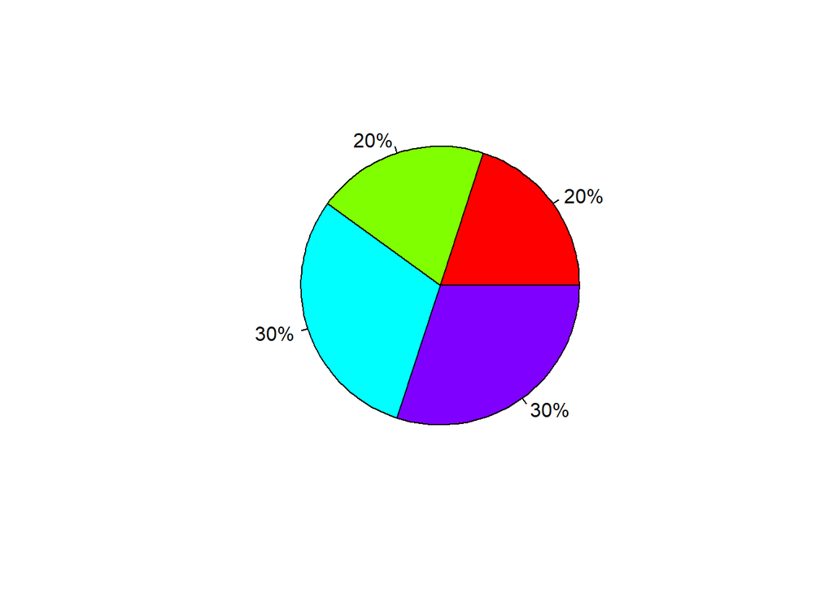

Ukázka jednoduchého koláčového grafu

#### 2.4.3 Číslicový histogram (*stem-and-leaf*)

Číslicový histogram je jinak známy jako *stem-and-leaf plot* a podobně histogramu pomáhá vizualizovat tvar rozdělení. Jedná se spíš o historický typ grafu, populární v osmdesátých letech, kdy vykreslování velkých datasetu bylo obtížnější. Vstupní údaje se rozdělí na dva sloupce rozdělené vertikální linii. Pravý sloupec obsahuje listy (*leaf*) - poslední číslici čísla či číslo po desetinné čárce a levý sloupec obsahuje stonek (*stem*) - zbylé číslice (čísla před desetinnou čárkou). Každý stonek se uvádí pouze jednou, aniž by se nějaký vynechal i kdyby to znamenalo, že nebude mít žádné listy. Listy se uvádějí v rostoucím pořadí. Tak v příkladu uvedeným níže, v prvním řádku stonkem je číslice -2, listy jsou číslice 9 a 2 a tak víme že v datasetu se vyskytli čísla -2.9 a -2.2. Tento typ grafu v prostředí R se vykresluje pomoci funkci `stem()`:

```r
stem(x)
```

```
##
##   The decimal point is at the |
##
##   -2 | 92
##   -1 | 888755333332211100
##   -0 | 99888877666666655554433332111100
##    0 | 0011122222233334444456777788888999
##    1 | 0233445689
##    2 | 0012
```

## 3 Průzkumová analýza dat

```r
DiagrammeR::mermaid("
graph LR
A(Problem)
A --> B(Získání dat);
B --> D(Průzkumová analýza dat);
D --> C;
B -->C(Volba modelu);
C -->E(Odhad modelu);
E --> F(Interpretace výsledků);
F --> G(Závěry);
G -->A;
")
```

[interactive chart not shown]

Úkolem průzkumové analýzy dat (*Explanatory Data Analysis*, zkráceně EDA) je vizualizace a transformace dat systematickým způsobem za účelem maximálního pochopení dat, určení vztahu mezi nimi a posouzení jejích kvality. Průzkumová analýza dat není specifikována jako konkretní soubor pravidel a postupu. EDA je důležitou části datové analýzy a měla by být jedním z prvních kroků. [3]

Fisher & Tukey [11]

### 3.1 Odlehlá pozorování

Odlehlá pozorování (*outliers*) jsou pozorování, která jsou vzdálená vůči ostatním hodnotám datasetu. Definice toho, jak moc vzdálené takováto pozorování mají být je na analytikovi, který to určí na základě pozorování daných konkretním datasetem a kontextu problematiky. Tato pozorování mohou být indikátorem chybných dat nebo vzácných událostí a mělo by být pečlivě zkoumány proč se vyskytli a jak moc ovlivňují zájmový dataset.

V momentech, kdy je vizualizace obtížná (velké datasety, větší množství proměnných, atd.), využivají se nástroje vícerozměrné, například Mahalanobisovy vzdalenosti (*Mahalanobis distance*), Leverages, OLS $\dots$

#### 3.1.1 *Jacknife*

#### 3.1.2 Mahalanobisovy vzdalenosti

#### 3.1.3 Leverages

#### 3.1.4 OLS

### 3.2 Náhrada chybějících pozorování

### 3.3 Transformace dat

### 3.4 Změna typu proměnných

### 3.5 Ověřování normality

# Praktická část

## 4 Praktická vizualizace dat

### 4.1 Prostředí R

#### 4.1.1 Balíčky

#### 4.1.2 …

### 4.2 Balíčky pro vizualizaci dat

#### 4.2.1 ggplot2

#### 4.2.2 lattice

#### 4.2.3 rgl

### 4.3 Balíčky pro interaktivní vizualizaci dat (htmlwidgets)

#### 4.3.1 plotly

#### 4.3.2 dygraphs

#### 4.3.3 leaflet

#### 4.3.4 ggvis

### 4.4 Balíčky pro prostorová data

#### 4.4.1 ggmap

### 4.5 …

#### 4.5.1 raster

#### 4.5.2 rasterVis

### 4.6 Balíčky pro webové aplikace

#### 4.6.1 shiny

#### 4.6.2 flexdashboard

#### 4.6.3 dashboard

# Literatura

[1] Chang, W. 2012. *R graphics cookbook: Practical recipes for visualizing data*. O’Reilly Media.

[2] Cleveland, W.S. 1994. *The elements of graphing data*. Hobart Press.

[3] Grolemund, G. and Wickham, H. 2016. *R for data science*. Hadley Wickham.

[4] Histogram - wikipedia: [vid. 6.8.2017]. *https://en.wikipedia.org/wiki/Histogram*.

[5] Maciejewski, R. 2011. *Data representations, transformations, and statistics for visual reasoning*. Morgan & Claypool Publishers.

[6] Novovičová, J. 2006. *Pravděpodobnost a matematická statistika*. Praha: Vydavatelství ČVUT,

[7] P–P plot - wikipedia: [vid. 11.8.2017]. *https://en.wikipedia.org/wiki/P%E2%80%93P_plot*.

[8] R: Generic x-y plotting: [vid. 11.5.2017]. *https://stat.ethz.ch/R-manual/R-devel/library/graphics/html/plot.html*.

[9] R: The r graphics package: [vid. 22.4.2017]. *https://stat.ethz.ch/R-manual/R-devel/library/graphics/html/graphics-package.html*.

[10] Teetor, P. 2011. *R cookbook: Proven recipes for data analysis, statistics, and graphics*. O’Reilly Media.

[11] Tukey, J.W. 1977. *Exploratory data analysis*. ADDISON WESLEY PUB CO INC.

[12] Wilkinson, L., Wills, D., Rope, D., Norton, A. and Dubbs, R. 2006. *The grammar of graphics*. Springer New York.